# Group model solution landscapes

Mikael Ohlsson

2024-05-17

## Food web data formatting

Makes adjacency matrices for each iteration to be run by the group model, and separate files for their species data.

```r
weblist <- list.files(path = "../data/food_webs_pw")
webshort <- str_replace(weblist, ".txt", "")

# Create folders if needed
if(length(list.dirs(path = "../data/adjmat/")) == 0) dir.create(path = "../data/adjmat")
if(length(list.dirs(path = "../data/sp/")) == 0) dir.create(path = "../data/sp")

# Check if adj matrices already exist
if(length(list.files(path = "../data/adjmat")) <500) {
# If not, get on with it
  for(n in 1:length(weblist)){
    net.adj <- read_delim(file = paste0("../data/food_webs_pw/", weblist[n]), delim = " ") %>%
    graph.data.frame() %>%
    as_adjacency_matrix() %>%
    as.matrix() %>%
    as.data.frame()

    # 100 iterations of adjacency matrices
    for(i in 1:100){

      write_delim(x = net.adj,
                   file = paste0("../data/adjmat/",
                                 webshort[n],
                                 "_",
                                 str_pad(i, width = 4, pad = "0"),
                                 ".txt"),
                   delim = " ",
                   col_names = F)

     # And separate files with species names associated to specific rows/columns
      net.adj %>%
           rownames_to_column() %>%
           pull(var=1) %>%
           list() %>%
           fwrite(file=paste0("../data/sp/sp_",
                              webshort[n],
                              "_",
                              str_pad(i, width = 4, pad = "0"),
                              ".txt"))
    }
  }
}
```

# Group model runs

Running the group model for all the generated adjacency matrices. As we manually created separate adjacency matrix iterations, we set number of “runs” here to 1. Note that this is very time consuming (approx. 3000 hours) and should be parallelized.

```r
#First, checking if result files already exist. If not, running the group model. Very time consuming unless run in parallel.

if(length(list.files("../results/original")) < 500){
  setwd("../GroupModelAlgorithm")
  adjfolder <- "../data/adjmat/"

  netlist <- list.files(path = adjfolder, pattern = "*.txt$", full.names = T)
  netnames <- list.files(path = adjfolder, pattern = "*.txt$", full.names = F)

  #Number of MCMC steps
  steps <- as.character("200000")

  #Number of MCMC chains
  chains <- 20

  #Number of runs per network (runs with identical solutions will overwrite each other and thus cant be tallied)
  runs <- 1

  #Max number of groups per network
  groups <- 20

  for(i in 1:length(netlist)){
    for(j in 1:runs) {
      r <- as.character(floor(runif(1, min=100001, max=1000000))) #random seed
    exec <- paste("./FindGroups", ncol(read.delim(netlist[i], sep = " ", header=F)), netlist[i], r, steps, chains, groups, 0)
  #AFTER groups, 0 flag to deactivate degree correction  OR
  #1, 1, 1 flags to activate degree correction
  system(exec)
    }
  }
  setwd("../code")

  # Group model output data uses the same folder as source food webs. Hence, after finishing, moving group model result files to result folder:
  if(!"original" %in% list.dirs("../results", full.names = F)) dir.create("../results/original")

  movefiles <- list.files("../data/adjmat", pattern = ".txt-G")
  targetlocation <- paste0("../results/original/", movefiles)
  file.rename(from = paste0("../data/adjmat/", movefiles), to = targetlocation)
}
```

# Fetch group data function

Function to generate data frame with results from group model

```r
Collect_Results <- function(foldername) {
  results <- list.files(path = paste0("../results/", foldername), pattern = "Marginal") #%>%
  species <- list.files(path = paste0("../data/sp"), pattern = "*.txt$") %>%
    as_tibble() %>%
    filter(str_detect(value, str_c(substr(results, 0,10), collapse="|"))) %>%
    pull(value)


  df <- tibble(web = "a",
               iter = 0.1,
               marginal = 0.1,
               species = "a",
               group = 0.1) %>%
    .[-1,]

  for(i in 1:length(results)) {
    tmp_grp <- scan(file = paste0("../results/",foldername,"/",results[i]))
    tmp_sp <- scan(file = paste0("../data/sp/",species[i]), sep = "\n", what = "character")
    tmp_df <- tibble(web = substr(results[i], 1, 5),
                     iter = as.numeric(substr(results[i], 7,10)), #7, 10
                     marginal = as.numeric(substr(results[i], 51,75)), #51,75
                     species = tmp_sp,
                     group = tmp_grp + 1
                     ) %>%
      mutate(species = str_replace_all(species, "\\.", "_")) %>%
      mutate(species = str_replace_all(species, " ", "_"))
    df <- bind_rows(df, tmp_df)
  }
  return(df)
}


#Used for plot titles etc

webrename <- function(df) {
  df %>%
  mutate(web = case_when(web == "baren" ~ "Barents Sea (S=233)",
            web == "kongs" ~ "Kongsfjorden (S=268)",
            web == "reefs" ~ "Reef (S=249)",
            web == "stmks" ~ "St. Marks (S=143)",
            web == "ythan" ~ "Ythan (S=92)")) %>%
    mutate(web = fct_relevel(web, c("Ythan (S=92)","St. Marks (S=143)","Barents Sea (S=233)","Reef (S=249)","Kongsfjorden (S=268)"))) %>%
    return()
}

group_df <- Collect_Results("original")
```

# Function for Jaccard Distance

Finds the best group structure (marginal likelihood-based) for each food web, and compares it to all other group structure iterations.

```r
Jaccard_Distance <- function(df){
  GroupAll <- tibble()
  webs <- df %>%
    distinct(web) %>%
    pull()

  # Create one DF per web and cut type (link removal, species removal).
  # base_df is the "best" group solution to which all other networks will be compared
  # Only link removal ("lr0") has 100 iterations of fraction 1, thus only selecting from those results
  # compare_df is the full collection of group results (i.e. all iterations for all fractions removed)
  #
  for(w in 1:length(webs)){
    base_df <- df %>% # Base is the "best" grouping as in highest marginal likelihood
      filter(web == webs[w]) %>%
      filter(marginal == max(marginal)) %>%
      group_by(species) %>%
      slice(1) %>% # If multiple iterations give the same grouping, picking the first one
      ungroup() %>%
      dplyr::select(species, group) # Best (marginal likelihood) original web group structure to which the reduced networks are compared

      time1 <- Sys.time()
      compare_df <- filter(df, web == webs[w])

      tmp_df <- compare_df %>%
      dplyr::select(iter, species, group) %>%
      left_join(base_df, ., by=c("species"))

        fetchsp.x <- function(g1) {
          base_df %>%
            filter(group == g1) %>%
            pull(species) %>%
            return()
        }

        fetchsp.y <- function(i,g2) {
          tmp_df %>%
            filter(iter == i & group.y == g2) %>%
            pull(species) %>%
            return()
        }

            GroupJ <- tmp_df %>%
              group_by(iter, group.x) %>%
              count(group.y) %>%
              filter(n == max(n)) %>%
              slice(1) %>%
              ungroup() %>%
              mutate(sp.x = pmap(.l = list(group.x), fetchsp.x)) %>%
              mutate(sp.y = pmap(.l = list(iter, group.y), fetchsp.y)) %>%
              rowwise() %>%
              mutate(sp.intersect = list(intersect(unlist(sp.x), unlist(sp.y)))) %>%
              mutate(sp.union = list(union(unlist(sp.x), unlist(sp.y)))) %>%
              mutate(GroupJs = length(unlist(sp.intersect)) / length(unlist(sp.union))) %>%
              ungroup() %>%
              mutate(web = webs[w])

            GroupAll <- bind_rows(GroupAll, GroupJ)

            time2 <- Sys.time()
            dtime <- as.numeric((time2-time1), units = "mins")

            message(sprintf("web %s taking %g minutes", webs[w], dtime))
  }
            return(GroupAll)
}

# Average Jaccard similarity per web and fraction
WebJs <- function(df) {
  df %>%
    group_by(web) %>%
    summarise(Js = mean(GroupJs)) %>%
    ungroup () %>%
    return()
}

# Web Jaccard similarity for each fraction and iteration
IterJs <- function(df) {
  df %>%
    group_by(web, iter) %>%
    summarise(Js = mean(GroupJs)) %>%
    ungroup () %>%
    return()
}

# Jaccard Similarity for each group
GroupJs <- function(df) {
  df %>%
    group_by(web, group.x) %>%
    summarise(GroupJs = mean(GroupJs)) %>%
    ungroup () %>%
    return()
}

J_df <- Jaccard_Distance(group_df)
```

## Jaccard similarity (Fig. 1)

Group structure similarity measured in Jaccard similarity for 100 iterations per food web, when compared to their respective (ML-based) best group structures.

```r
gg_Js <- J_df %>%
  IterJs() %>%
  webrename() %>%
  ggplot() +
  aes(x = Js) +
  geom_histogram(binwidth = 0.02, position = position_dodge()) +
  facet_grid(.~web) +
  labs(y = "Bin count", x = "Jaccard similarity")
```

```
## argument.
```

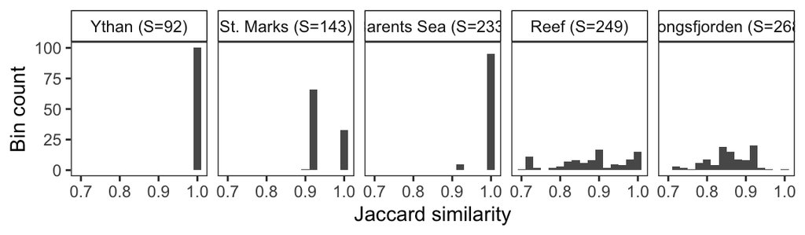

```r
gg_Js
```

```r
ggsave(filename = "../results/fig1.pdf", height = 1.75, width = 6)
```

Latex formatted table with the top 10 best solutions and the number of iterations which resulted in the same solutions (n)

```r
group_df %>%
  distinct(web, iter, marginal) %>%
  group_by(web) %>%
  count(marginal) %>%
  arrange(web, -marginal) %>%
  left_join(group_df %>%
              dplyr::select(web, iter, marginal) %>%
              group_by(web, marginal) %>%
              slice(1), #if multiple identical structures, just pick one
            by = c("web", "marginal")) %>%
  slice(1:10) %>% # select top 10 ML per web
  dplyr::select(-iter) %>%
  webrename() %>%
  xtable()
```

```
## % latex table generated in R 4.3.0 by xtable 1.8-4 package
## % Fri May 17 12:04:47 2024
## \begin{table}[ht]
## \centering
## \begin{tabular}{rlrr}
##   \hline
##  & web & marginal & n \\
##   \hline
## 1 & Barents Sea (S=233) & -6248.68 &  95 \\
##   2 & Barents Sea (S=233) & -6251.24 &   5 \\
##   3 & Kongsfjorden (S=268) & -3893.49 &   1 \\
##   4 & Kongsfjorden (S=268) & -3895.94 &   1 \\
##   5 & Kongsfjorden (S=268) & -3897.47 &   1 \\
##   6 & Kongsfjorden (S=268) & -3898.15 &  11 \\
##   7 & Kongsfjorden (S=268) & -3901.52 &   2 \\
```

[output cut: 23 more lines]

# Compare all combinations of group structures

Basis for the solution landscape plots. Group structure comparisons of all possible combinations of group structure iterations calculated. Takes about 10 minutes.

```r
AllJs <- function() {
compare_df <- group_df

#Checking which species are present in the best fitting groups
checksp <- function(w, i, s){
  compare_df %>%
    filter(web == w & species %in% unlist(s)) %>%
    group_by(web, iter) %>%
    count(group) %>%
    filter(n == max(n)) %>%
    group_by(web, iter) %>%
    slice(1) %>% #Pick one iteration in case of multiple iterations with the same group structure
    ungroup() %>%
    left_join(dplyr::select(compare_df, web, iter, group, species),
              by = c("web", "iter", "group")) %>%
    group_by(web, iter, group, n) %>%
    nest() %>%
    rename(species = data) %>%
    return()
}

#Measuring Jaccard index, takes a couple of minutes (9 min?)
J_tmp <- compare_df %>% #filter(web == "stmks") %>%
  as_tibble() %>%
  group_by(web, iter, marginal, group) %>%
  nest() %>% #Nest species
  rename(sp = data) %>%
  ungroup() %>%
  mutate(sp.best = pmap(list(web, iter, sp), checksp)) %>%
  unnest(sp.best, names_sep = "_") %>%
  rowwise() %>%
  mutate(sp.union = list(union(unlist(sp), unlist(sp.best_species)))) %>%
  mutate(J_group = sp.best_n / length(sp.union)) %>%
  ungroup() %>%
  rename(ix = iter, iy = sp.best_iter,
          mx = marginal, Js = J_group)
}

AllJs_df <- AllJs()
```

# Solution landscapes (Fig. 2)

Excluding St. Marks and Ythan due to very low variability. The Barents Sea food web is highly concentrated to two solutions and thus does not display a density plot.

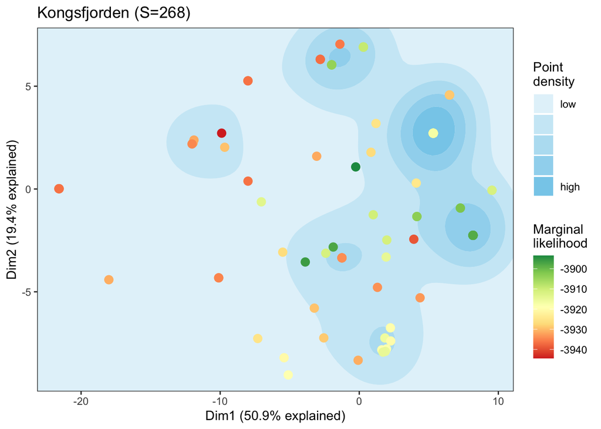

```r
dist_plot <- function(w) {

  #For fancy plot titles
  fancy_w <- tibble(web=w) %>% webrename() %>% pull(web)

  # Summarising the groupwise jaccard indices to iterations and naming iterations according to fraction links removed
  dist_df <- AllJs_df %>% ungroup() %>%
    group_by(web, ix, mx, iy) %>%
    summarise(Js = mean(Js)) %>%
    ungroup() %>%
    filter(web == w) #%>%
    # mutate(A_f_i = paste0("","_",ix),
    #        B_f_i = paste0("","_",iy))

  #Convert to matrix
  dist_mx <- dist_df %>%
    #filter(sp.best_frac == 1) %>% # # # # # #
    dplyr::select(ix, iy, Js) %>%
    pivot_wider(names_from = "ix", values_from = "Js") %>%
    dplyr::select(-iy) %>%
    as.matrix()

  # What is the matrix ... row names
  dimnames(dist_mx)[1] <- dist_df %>% #filter(sp.best_frac == 1) %>% # ## # #
    dplyr::select(ix, iy, Js) %>%
    pivot_wider(names_from = "ix", values_from = "Js") %>%
    pull(iy) %>%
    list()

  # Run a PCA to reduce dimensions
  pcatmp <- dist_mx %>%
    PCA(graph = F)

  # FactoMineR PCA plot to get coordinates
  gtmp <- pcatmp %>%
    plot(choix = "ind")

  # Grab data from the previous plot and add fractions and marginal likelihoods to the iterations
  ggdata <- ggplot_build(gtmp)$data[[4]] %>%
    left_join(dist_df %>%
                dplyr::select(ix, mx) %>%
                distinct() %>%
                mutate(ix = as.character(ix)), by = c("label" = "ix")) %>%
    rowwise() %>%
    #Adding a (visually non-noticeable) noise to help plotting really dense areas
    mutate(x = x * (1-0.001*runif(1,-1,1)),
           y = y * (1-0.001*runif(1,-1,1))) %>%
    ungroup()

  # Used to expand plot area slightly to avoid clipping points at the edges
  e_x <- 0.05*diff(c(min(ggdata$x),max(ggdata$x)))
  e_y <- 0.05*diff(c(min(ggdata$y),max(ggdata$y)))

  # Make a complete ggplot of the PCA
  ggdata %>%
    as_tibble() %>%
    mutate(label = str_replace(label, "1_", "")) %>%
    ggplot() +
    aes(x,y, label = label, color = mx) +
    stat_density2d_filled(aes(alpha = ..level..), fill = "skyblue", #
                          bins = 5, adjust = 5/6) +
    geom_jitter(size = 3, show.legend = F) +
    scale_alpha_discrete(range = c(0.25,1), labels = c("low","","","","high")) +
    # geom_text_repel(max.overlaps = 200, size = 3, alpha = 1/2, fontface = "bold") +
    scale_color_distiller(palette = "RdYlGn", direction = 1) +
    #scale_fill_distiller(palette = "Spectral", direction = -1) +
    #scale_x_continuous(exp)
    scale_x_continuous(limits = c(min(ggdata$x)-e_x, max(ggdata$x)+e_x)) +
    scale_y_continuous(limits = c(min(ggdata$y)-e_y, max(ggdata$y)+e_y)) +
    guides(alpha = guide_legend(order = 1), fill = guide_legend(order = 2)) +
#    scale_fill_gradient(low = "lightblue", high = "#7777BB") +
    labs(title = fancy_w,#paste0("PCA of the ", fancy_w, " group structure iteration dissimilarities"),
         #subtitle = "Group structure dissimilarity (point distance) and solution marginal likelihood (color)",
         color = "Marginal\nlikelihood",
         alpha = "Point\ndensity",
         shape = "Fraction links") +
    coord_cartesian(expand = FALSE) +
#    lims(x = c(-46,15), y = c(-10,12)) +
    labs(x = paste0("Dim1 (",round(pcatmp$eig[1,2],1), "% explained)" ),
         y = paste0("Dim2 (",round(pcatmp$eig[2,2],1), "% explained)" )) +
    theme_bw() +
    theme(panel.grid = element_blank(),
          panel.background = element_rect(fill = "white")) %>%
    return()
}

#dist_plot("baren") # Not enough spread for density plot
dist_plot("kongs")
```

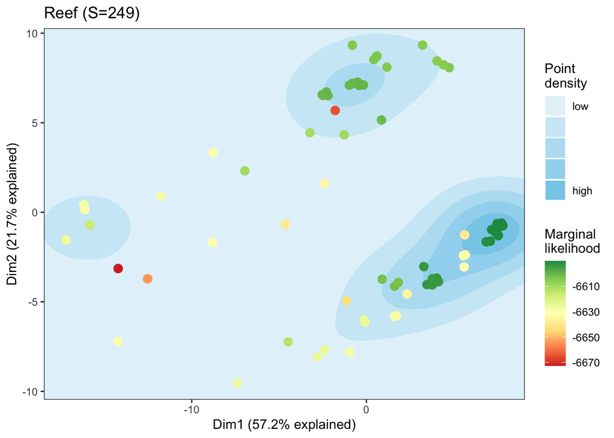

```r
dist_plot("reefs")
```

```r
#dist_plot("stmks") # very limited variation
#dist_plot("ythan") # no variation (mind, only jitter variation if still plotting)
plot_grid(dist_plot("reefs"), dist_plot("kongs"), ncol = 2) %>%
ggsave(filename = "../results/fig2.pdf", height = 4, width = 9.75)
```

# Pairwise species stability analysis

Here we look at how often species pairs are in the same group in different group structure iterations of the same network.

```r
GroupStability <- function(webname) {
  StabDF <- tibble(Var1="a", Var2="a", value=0.1, web="a") %>% .[-1,]

    # The number of times the species pairs are in the same group
    for(w in 1:length(webname)){
        group_matrix <- group_df %>%
          filter(web == webname[w]) %>%
          dplyr::select(species, group, iter) %>%
          mutate(n = 1) %>%
          spread(species, n, fill = 0) %>%
          dplyr::select(-group, -iter) %>%
          {crossprod(as.matrix(.))}

      # The number of times they occur in the food web (i.e. 100%)
        total_matrix <- group_df %>%
          filter(web == webname[w]) %>%
          dplyr::select(species, iter) %>%
          mutate(n = 1) %>%
          spread(species, n, fill = 0) %>%
          dplyr::select(-iter) %>%
          {crossprod(as.matrix(.))}

        # The proportion of which the species pairs are grouped together
        StabTmp <- (group_matrix / total_matrix) %>%
          as.data.frame.table() %>% as_tibble()

        StabDF <- bind_rows(StabDF, tibble(Var1 = StabTmp$Var1,
               Var2 = StabTmp$Var2,
               value = StabTmp$Freq,
               web = webname[w]))
  }
  return(StabDF)
}
```

## Running group stability function

Also adds original group membership to species from the best fit grouping (ML-based).

```r
basicwebs <- c("baren", "kongs", "reefs", "stmks", "ythan")

StabDF <- GroupStability(basicwebs)

StabDF.addgroups <- function(df) {
  webname <- StabDF %>% distinct(web) %>% pull()
  StabDF_gr <- list()

  for(i in 1:length(webname)){
    StabDF_gr[[i]] <- StabDF %>%
      filter(web == webname[i]) %>%
      left_join(group_df %>%
                  filter(web == webname[i]) %>%
                  filter(marginal == max(marginal)) %>%
                  group_by(species) %>%
                  slice(1) %>%
                  dplyr::select(species, web, group),
                by = c("Var1" = "species", "web")) %>%
      left_join(group_df %>%
                  filter(web == webname[i]) %>%
                  filter(marginal == max(marginal)) %>%
                  group_by(species) %>%
                  slice(1) %>%
                  dplyr::select(species, web, group),
                by = c("Var2" = "species", "web"))
  }
  StabDF_gr <- tibble(A = StabDF_gr) %>% unnest(cols = c(A))
  return(StabDF_gr)
}
StabDF_gr <- StabDF.addgroups(StabDF)
```

### Heatmap function

Arranges species for each food web along the x- and y-axis according to their best group structures.

```r
# Function used for plotting purposes when arranging species.
original_groups <- function(webname) {
  original <- group_df %>%
    filter(web %in% webname) %>%
    filter(marginal == max(marginal)) %>%
                  group_by(species) %>%
                  slice(1) %>%
    ungroup() %>%
    dplyr::select(species, group, iter)
  sp_order <- original %>% arrange(group)# %>% pull(species)
  return(sp_order)
}


# Main plotting function

CheatPlot <- function(webname) {
  # Checking original number of groups (used for coloring)
  webtitle <- tibble(web = webname) %>% webrename() %>% pull(web)
  clen <- original_groups(webname) %>% pull(group) %>% n_distinct()

      # Heatmap Annotations with group color codings taken from the RColorBrewer package.
   top_ha <- HeatmapAnnotation(Group = original_groups(webname) %>% arrange(group) %>%
                                 pull(group),
                           col = list(Group = tibble(A = original_groups(webname) %>%
                                                       distinct(group) %>%
                                                       mutate(group = as.factor(group)) %>%
                                                       pull(group),
                                                     B = c(brewer.pal(name="Paired", n = 8),
                                                           brewer.pal(name="Dark2", n = 8))[1:clen]) %>%
                                        arrange(A) %>%
                                        deframe()),
                          show_legend = F,
                          show_annotation_name = F)



   left_ha <- rowAnnotation(Group = original_groups(webname) %>%
                              mutate(group = as.factor(group)) %>%
                              dplyr::pull(group),
                           col = list(Group = tibble(A = original_groups(webname) %>%
                                                       distinct(group) %>%
                                                       mutate(group = as.factor(group)) %>%
                                                       pull(group),
                                                     B = c(brewer.pal(name="Paired", n = 8),
                                                           brewer.pal(name="Dark2", n = 8))[1:clen]) %>%
                                        arrange(A) %>%
                                        deframe()),
                          show_annotation_name = F)

    pheatdata <- StabDF_gr %>%
      dplyr::select("Var1", "Var2", "value", "web") %>%
      filter(web == webname) %>%
      pivot_wider(values_from = value, names_from = c(Var2)) %>%
      dplyr::select(-c("web")) %>%
      set_rownames(.$Var1) %>%
      data.matrix(rownames.force = T) %>%
      .[,-1] %>%
      .[(original_groups(webname) %>% arrange(group) %>% dplyr::pull("species")),] %>%
      .[,(original_groups(webname) %>% arrange(group) %>% dplyr::pull("species"))]

    Heatresult <- ComplexHeatmap::Heatmap(pheatdata, name = "Same \ngroup",
                            col = colorRampPalette(c("white", "grey", "black"))(50),
                            cluster_rows = F,
                            cluster_columns = F,
                            show_column_names = F,
                            show_row_names = F,
                            top_annotation = top_ha,
                            left_annotation = left_ha,
                            column_title = webtitle)

  return(Heatresult)
}
```

### Heatmaps (Fig. 3)

Species arranged in groups based on the best fit (ML) result

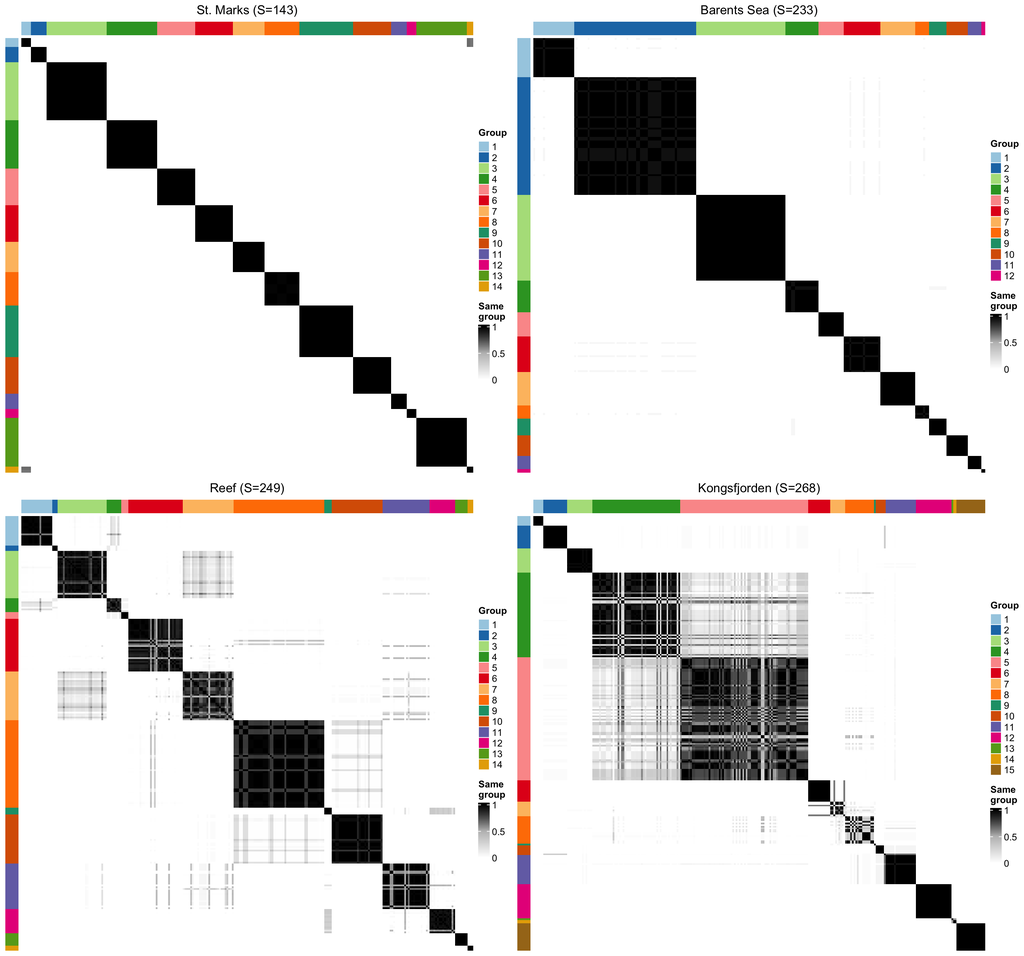

```r
cheat_baren <- CheatPlot("baren")
cheat_kongs <- CheatPlot("kongs")
cheat_reefs <- CheatPlot("reefs")
cheat_stmks <- CheatPlot("stmks")
#cheat_ythan <- CheatPlot("ythan") # Skipping Ythan as it only has one group structure solution

cheat_grid <- plot_grid(grid.grabExpr(draw(cheat_stmks)), grid.grabExpr(draw(cheat_baren)),
          grid.grabExpr(draw(cheat_reefs)), grid.grabExpr(draw(cheat_kongs)), #grid.grabExpr(draw(cheat_ythan)),
          ncol = 2,
          #labels = c("A", "B", "C", "D", "E"),
          hjust = -0.4)

cheat_grid
```

```r
ggsave(filename = "../results/fig3.pdf", plot = cheat_grid, width = 9.5, height = 9)
```

# Species data

Species taxonomies for the Barents Sea were obtained from Kortsch et al. (2018), while taxonomies for all other networks were obtained from Cirtwill & Eklöf (2018, and references therein).

```r
TraitsDF <- read_csv(file = "../data/food_webs_data/full_data_upd.csv") %>%
  mutate(Network = case_when(Network == "baren" ~ "Barent's Sea",
            Network == "baske" ~ "Serengeti",
            Network == "kongsfjorden" ~ "kongs",
            Network == "reef" ~ "reefs",
            Network == "stmarks" ~ "stmks",
            Network == "ythanjacob" ~ "ythan")) %>%
  dplyr::select(Network, Species, Group, Kingdom, Phylum, Class, Order, Family,
                Genus, BodyWeight, FeedingMode, MetabolicCategory, FeedingType,
                Mobility, Environment) %>%
  bind_rows((read_tsv(file = "../data/kortsch/SpeciesList.txt") %>% #Limited to taxonomy for Barents Sea, also adding genus column from species name
  rename(Species = ABBREVIATION, Phylum = PHYLUM_SUBPYLUM,
         Class = CLASS, Order = ORDER, Family = FAMILY) %>%
  mutate(Network = "baren") %>%
  mutate(TROPHOSPECIES = str_to_sentence(TROPHOSPECIES)) %>%
  separate(TROPHOSPECIES, into = c("Genus", "xx"), sep = "_") %>%
  dplyr::select(-"xx", -"GROUP"))
              ) %>%
      mutate(Species = str_replace_all(Species, "\\.", "_")) %>%
      mutate(Species = str_replace_all(Species, " ", "_"))
StabDF_Traits <- StabDF_gr %>%
  mutate(Var1 = str_replace(Var1, pattern="___", replacement="_"),
         Var2 = str_replace(Var2, pattern="___", replacement="_")) %>%
  left_join(TraitsDF, by = c("Var1" = "Species", "web" = "Network")) %>%
  left_join(TraitsDF, by = c("Var2" = "Species", "web" = "Network"))
```

## Taxonomic similarities (Fig. 4)

Adding closest taxonomic relationship for all species pairs which were found in the same group.

```r
pw_taxa_data <- StabDF_Traits %>%
  filter(Var1 != Var2) %>%
  filter(group.x == group.y & web %in% c("kongs", "reefs")) %>%
  mutate(TaxSim = ifelse(!is.na(Phylum.x) & !is.na(Phylum.y) & Phylum.x == Phylum.y, "Phylum", "Unrelated")) %>%
  mutate(TaxSim = ifelse(!is.na(Class.x) & !is.na(Class.y) & Class.x == Class.y, "Class", TaxSim)) %>%
  mutate(TaxSim = ifelse(!is.na(Order.x) & !is.na(Order.y) & Order.x == Order.y, "Order", TaxSim)) %>%
  mutate(TaxSim = ifelse(!is.na(Family.x) & !is.na(Family.y) & Family.x == Family.y, "Family", TaxSim)) %>%
  mutate(TaxSim = ifelse(!is.na(Genus.x) & !is.na(Genus.y) & Genus.x == Genus.y, "Genus", TaxSim)) %>%
  mutate(TaxSim = as.factor(TaxSim),
    TaxSim = fct_relevel(TaxSim, c("Unrelated", "Phylum", "Class", "Order", "Family", "Genus"))) %>%
    group_by(grp = paste(pmax(Var1, Var2), pmin(Var1, Var2), sep = "_")) %>%
  distinct(grp, .keep_all = TRUE) %>%
  ungroup() %>%
  dplyr::select(-grp) %>%
  dplyr::select(web, Var1, Var2, value, TaxSim) %>%
  webrename() %>%
  group_by(web, TaxSim) %>%
  summarise(ncount = n(),
            meanTax = mean(value),
            sdTax = sd(value)) %>%
  ungroup() %>%
  mutate(TaxData = paste(paste0("n=", ncount),
                                paste0("m=", round(meanTax, digits = 3)),
                                paste0("sd=", round(sdTax, digits = 3)),
                                sep = " \n "))
```

```
## argument.
```

```r
TaxaTable <- ggplot(pw_taxa_data) +
  aes(x = TaxSim, y = 0, label = TaxData) +
  geom_label(fill = NA, size = 3.3, label.padding = unit(0.07, "lines")) +
  facet_grid(.~web) +
  theme(panel.grid = element_blank(),
        panel.border = element_blank(),
        strip.background = element_blank(),
        strip.text = element_blank(),
        axis.text.y = element_blank(),
        axis.ticks = element_blank(),
        axis.title.y = element_blank()
        ) +
  labs(x = "Species pairs' closest taxonomic relatedness")

gg_pw_close_taxa <- StabDF_Traits %>%
  filter(Var1 != Var2 & group.x == group.y &
          web %in% c("kongs", "reefs")) %>%
  mutate(TaxSim = ifelse(!is.na(Phylum.x) & !is.na(Phylum.y) & Phylum.x == Phylum.y, "Phylum", "Unrelated")) %>%
  mutate(TaxSim = ifelse(!is.na(Class.x) & !is.na(Class.y) & Class.x == Class.y, "Class", TaxSim)) %>%
  mutate(TaxSim = ifelse(!is.na(Order.x) & !is.na(Order.y) & Order.x == Order.y, "Order", TaxSim)) %>%
  mutate(TaxSim = ifelse(!is.na(Family.x) & !is.na(Family.y) & Family.x == Family.y, "Family", TaxSim)) %>%
  mutate(TaxSim = ifelse(!is.na(Genus.x) & !is.na(Genus.y) & Genus.x == Genus.y, "Genus", TaxSim)) %>%
  group_by(grp = paste(pmax(Var1, Var2), pmin(Var1, Var2), sep = "_")) %>%
  distinct(grp, .keep_all = TRUE) %>%
  ungroup() %>%
  mutate(TaxSim = as.factor(TaxSim),
         TaxSim = fct_relevel(TaxSim, c("Unrelated", "Phylum", "Class",
                                        "Order", "Family", "Genus"))) %>%
  dplyr::select(Var1, Var2, web, TaxSim, value) %>%
  webrename() %>%
  left_join(pw_taxa_data, by = c("web", "TaxSim")) %>%
  ggplot() +
  aes(x = TaxSim, y = value, fill = TaxSim, group = TaxSim) +
  geom_boxplot(position = position_dodge2(preserve = "single"), show.legend = F) +
  facet_grid(.~web, scales = "free_x", space = "free") +
  scale_y_continuous(expand = expansion(add = c(0.05,0.05)), limits = c(0,1), breaks = c(0,0.25,0.5,0.75,1)) +
  scale_fill_manual(values = c("#555555",rev(brewer.pal(5, "RdYlBu")))) +
  labs(x = "Species pairs' closest taxonomic relatedness", y = "Pairwise stability") +
  theme(axis.text.x = element_blank(),
        axis.ticks.x = element_blank(),
        axis.title.x = element_blank())
plot_grid(gg_pw_close_taxa, NULL, plot_grid(NULL,TaxaTable, ncol = 2, rel_widths = c(0.055,0.945)), ncol = 1, rel_heights = c(0.7,-0.025,0.26)) %>%
ggsave(filename = "../results/fig4.pdf", width = 8, height = 3.8)
```

# Trophic level (Fig. S1)

Obtaining the trophic level (using the NetIndices package v. 1.4.4.1) of each species in the respective food webs and visualizing with histograms.

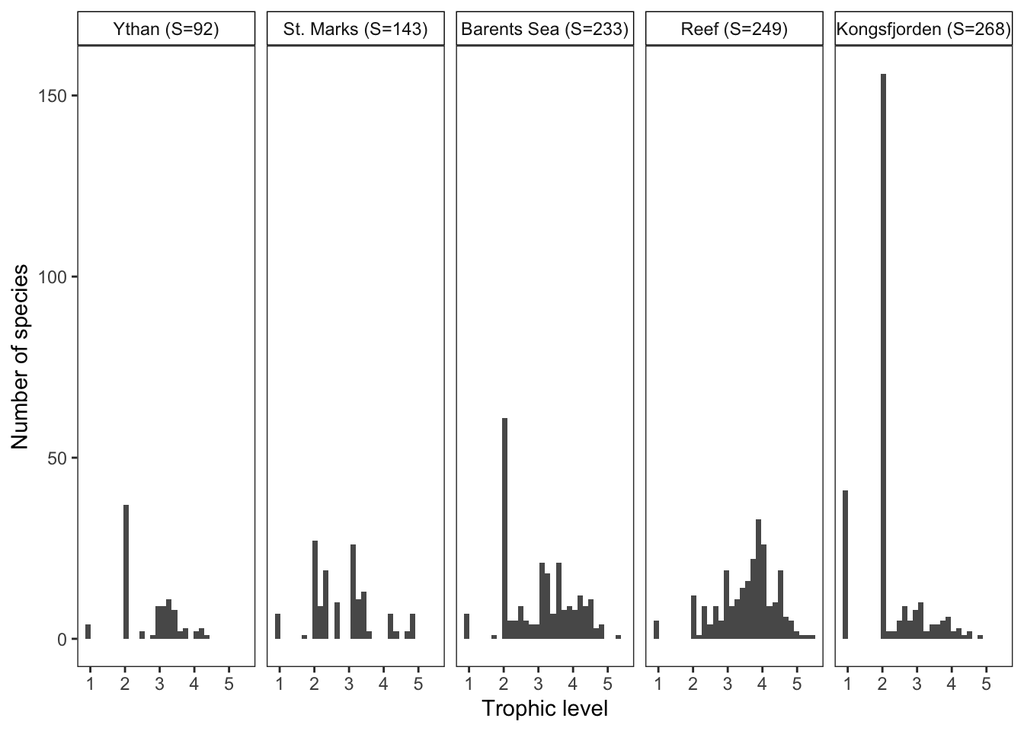

```r
MakeTL_Sp_list <- function(){
    TL_sp <- tibble() #directories to measure TL in (only unmodified networks used)

    # Load one each of each food web adjacency matrix
    networks <- list.files(path = "../data/adjmat/",
                           pattern = "*.txt$") %>%
      str_subset(c("_0001"), negate = FALSE)

    # Species vectors for matrix dims
    species <- list.files(path = "../data/sp/",
                          pattern = "*.txt$") %>%
      str_subset(c("_0001"), negate = FALSE)

    # Combine adj matrices and species vectors
    for(i in 1:length(networks)){
                tmp_ints <- read.delim(file = paste0("../data/adjmat/",networks[i]),
                             header = F, sep = " ") %>% as.matrix()

                tmp_sp <- scan(file = paste0("../data/sp/",species[i]),
                     sep = "\n", what = "character") %>%
                  str_replace_all("\\.", "_") %>%
                  str_replace_all(" ", "_")

      dimnames(tmp_ints) <- list(tmp_sp, tmp_sp)
      tmp_mat <- matrix(data = 0, nrow = nrow(tmp_ints), ncol = ncol(tmp_ints))
      dimnames(tmp_mat) <- list(tmp_sp, tmp_sp)

      # Obtain TL using TrophInd
      TL_tmp <- TrophInd(Tij = tmp_ints) %>%
        dplyr::select(TL) %>%
        rownames_to_column() %>%
        as_tibble() %>%
        rename(species = 1) %>%
        mutate(web = substr(networks[i], 0, 5)) %>%
        mutate(species = str_replace(species, pattern="___", replacement="_"))




      TL_sp <- TL_sp %>% bind_rows(TL_tmp)
    }
  return(TL_sp)
}

TL_sp <- MakeTL_Sp_list()

gg_TL_dist <- TL_sp %>%
  webrename() %>%
  ggplot() +
  aes(x = TL) +
  geom_histogram() +
  facet_wrap(web~., ncol = 5) +
  labs(x = "Trophic level", y = "Number of species")
gg_TL_dist
```

```r
ggsave(plot = gg_TL_dist, filename = "../results/figs_tl.pdf", height = 2, width = 8)
```

# Taxa Distribution (Fig. S2)

Counting the number of species per class in each food web. Filtered to include only those with more than two species per class in at least one of the food webs for easier visualization.

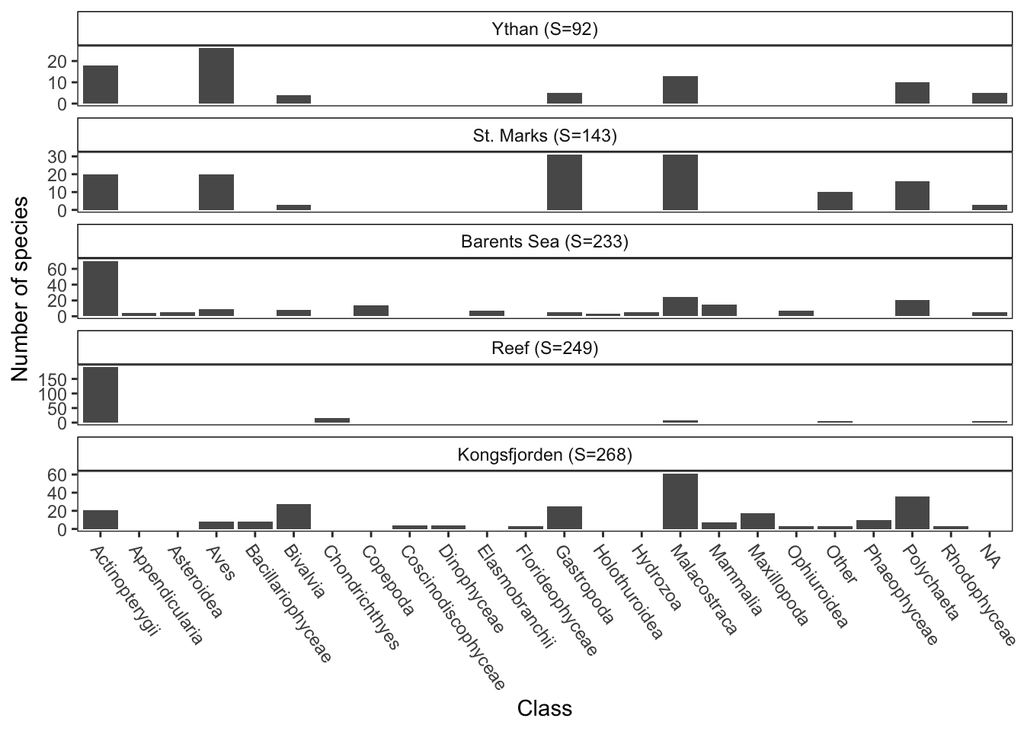

```r
gg_Taxa_dist <- TraitsDF %>%
  filter(!is.na(Network)) %>%
  group_by(Network) %>%
  count(Class) %>%
  ungroup() %>%
  filter(n > 2) %>%
  rename(web = Network) %>%
  webrename() %>%
  ggplot() +
  aes(x = Class, y = n) +
  geom_bar(stat = "identity", show.legend = F) +
  facet_wrap(web~., scales = "free_y", ncol=1) +
  theme(axis.text.x = element_text(angle = -55, hjust = 0)) +
  labs(y = "Number of species")
gg_Taxa_dist
```

```r
ggsave(plot = gg_Taxa_dist, filename = "../results/figs_taxa.pdf", height = 9, width = 6.5)
```

# Jaccard similarity vs Marginal likelihood (Fig. S4)

```r
gg_Js_ML <- group_df %>%
  filter(!web %in% c("ythan")) %>%
  dplyr::select(web, iter, marginal, group) %>%
  distinct() %>%
  left_join(J_df %>%
    dplyr::select(web, iter, group.x, GroupJs),
    by = c("web", "iter", "group" = "group.x")) %>%
  group_by(web, iter) %>%
  summarise(marginal = mean(marginal), Js = mean(GroupJs, na.rm = T)) %>%
  ungroup(iter) %>%
  mutate(marginal = marginal - max(marginal)) %>%
  distinct(web, marginal, Js) %>%
  webrename() %>%
  ggplot() +
  aes(x = marginal, y = Js) +
  geom_point() +
  facet_wrap(web~.) +
  labs(x = expression(paste(Delta, "Marginal likelihood")),
       y = "Jaccard similarity (vs. best solution)")
```

```
## argument.
```

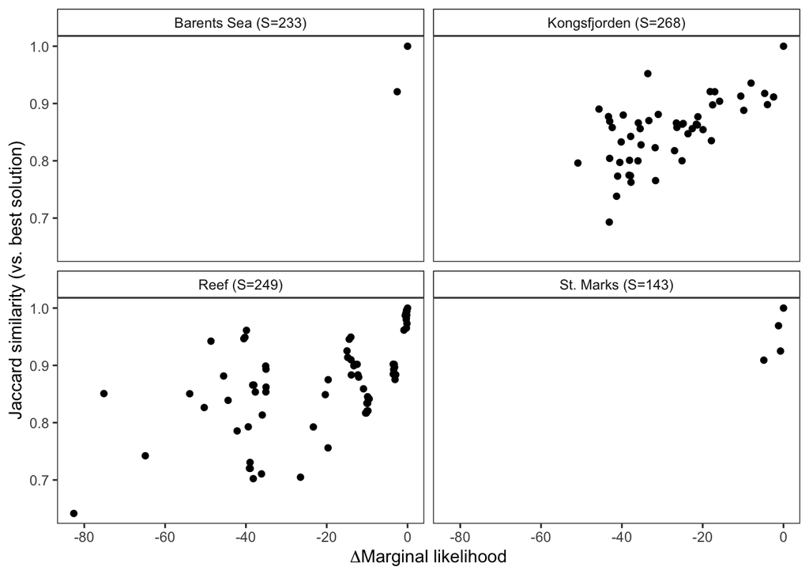

```r
gg_Js_ML
```

```r
ggsave(filename = "../results/figs_ml.pdf", plot = gg_Js_ML, width = 6.5, height = 6)
```

# Alluvial plot (Fig. S5)

An example plot visualizing the structural differences between two group structure iterations in Kongsfjorden.

```r
AlluPlotter <- function(u,v, net) {
AlluDF <- J_df %>%
  IterJs() %>%
  filter(web == net &
           iter %in% c(u,v)) %>%
  mutate(.r = ifelse(iter == u, 1, 2)) %>%
  left_join(group_df, by=c("web", "iter")) %>%
  left_join(TraitsDF, by = c("web" = "Network", "species" = "Species"))

  # Can be used for plot title
  CurrentJs <- AllJs_df %>%
    filter(web == net, ix == u, iy == v) %>%
    pull(Js) %>%
    mean() %>%
    round(3)

  # Can be used for plot title
  CurrentWeb <- AllJs_df %>%
    filter(web == net, ix == u, iy == v) %>%
    webrename() %>%
    pull(web)

  ggplot(AlluDF, aes(x=as.factor(.r), stratum=as.factor(group),
                                   alluvium=species, fill=as.factor(Phylum),
                                   label = as.factor(group))) +
  geom_flow(stat="alluvium", position="identity", reverse=F, lode.guidance="rightward", alpha = 1) + #aes.flow="forward", aes.bind=T,
  geom_stratum(reverse=F, width = 1/3, fill = "grey") +
  geom_text_repel(stat = "stratum", reverse=F, force = 0.0002) +
  theme_classic() +
  scale_x_discrete(labels = c(u,v), expand=c(0.2,0)) +
  scale_y_discrete(labels=AlluDF$species, name="Species") +
  scale_fill_manual(name="Phylum", values = c(brewer.pal(name="Set1", n = 9),
                                             brewer.pal(name="Set2", n = 8),
                                             brewer.pal(name="Paired", n = 12)
                                             )[1:29]) +
  theme(axis.text.x = element_text(size=12),
        axis.ticks.y = element_blank(),
        axis.title.y = element_blank(),
        axis.line.y = element_blank()) +
  guides(fill = guide_legend(ncol = 1)) +
  labs(#title = paste0("Original variation of ", CurrentWeb),
       #subtitle = paste0("Displaying iterations ", u, " and ", v, " with Jaccard similarity ", CurrentJs),
       x = "Iterations") %>%
  return()
}
gg_KongsAllu <- AlluPlotter(63,47,"kongs") #Js 0.856
```

```
## argument.
```

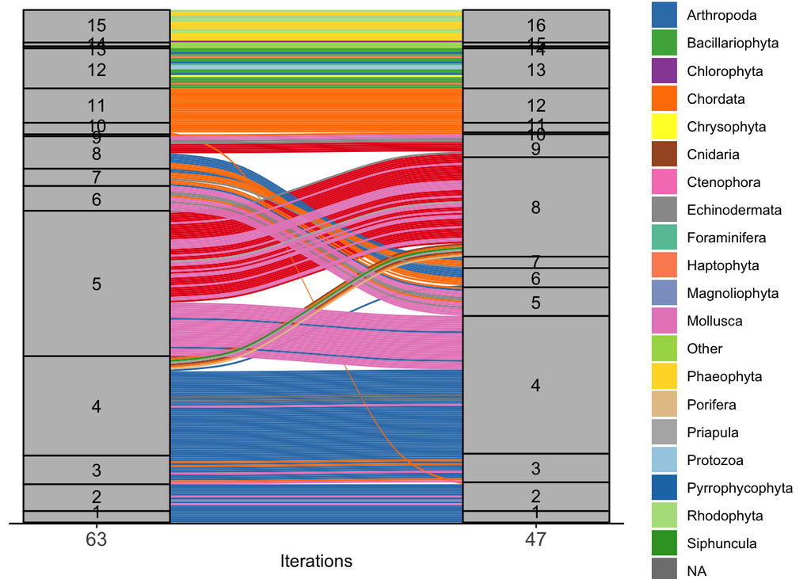

```r
gg_KongsAllu
```

```r
ggsave(filename = "../results/figs_allu.pdf", height = 7, width = 5)
```